# How to download and work with SNDOAS data

## 1. Tutorial Overview

This notebook demonstrates how to download and unzip masked SNODAS files that are from after October 2013 and select one variable and compile it into a RasterStack for quick visualization and finally save as a .grd file.

### Credits

This tutorial is based on an R script written in 2021 by Cara Thompson at New Mexico State University and has been converted to a tutorial with some minor additions by Jennifer Roebuck of NSIDC.

For questions regarding the tutorial or to report problems, please create a new issue in the [NSIDC-Data-Tutorials repo](https://github.com/nsidc/NSIDC-Data-Tutorials/issues)

### Learning Objectives

By the end of this demonstration you will be able to: 1. Download and unzip masked SNODAS files 2. Convert the files to .bil format and put them in a RasterStack 3. Quickly visualize the rasters of the data 4. Save the RasterStack as .grd file

### Prerequisites

1. The following libraries should already be installed: R.utils, rvest, dplyr, raster, sp, maptools, and data.table.

### Time requirement

Allow approximately 20 minutes to complete this tutorial.

## 2. Tutorial steps

### Load necessary libraries

```r
library(R.utils)
library(rvest)
library(dplyr)
library(raster)
library(sp)
library(maptools)
library(data.table)
```

### Download SNODAS data

We will download all the SNODAS masked files for June 2023. If you wish to download masked files from a different time period you can modify the path in the url variable below.

```r
# set the URL for the SNODAS directory we want to download files from
url <- "https://noaadata.apps.nsidc.org/NOAA/G02158/masked/2023/06_Jun"

# read html content from url
page <- read_html(url)

# Get a list of the files listed in the directory at this url
files <- page %>% html_nodes("a") %>% html_attr("href")

for(i in 2:length(files)){
  # generate the url for each of the files
  u <- paste(url,files[i], sep="/")
  # download each of the files
  download.file(u,files[i], mode = "wb")
}
```

We will save the working directory path to a variable.

```r
WD <- getwd()
```

### Read in the SNODAS files

Next, we read in the .tar files as a list containing .tar

```r
files_1 <- list.files(path = WD, pattern = "*.tar", full.names = T, recursive = T)
```

Decompress the .tar files into the working directory

```r
asd <- sapply(files_1, untar)
```

### Select the variable we wish to use

There are eight parameters from SNODAS, each has an associated ID code which is used the filename. A full description of the ID codes can be found in Table 1 of the [SNODAS user guide](https://nsidc.org/sites/default/files/g02158-v001-userguide_2_1.pdf). We will choose one of the parameters to compile all the files related to this parameter.

We can uncomment one of the variables below that corresponds to the parameter we are interested in. In this tutorial we will use the snow depth parameter as an example.

```r
id_code = "us_ssmv11036tS" # Snow Depth
#id_code = "us_ssmv11034tS" # SWE
#id_code = "us_ssmv11044bS" # Snow melt runoff at base of snow pack
#id_code = "us_ssmv11050IL00" # Sublimation from the snow pack
#id_code = "us_ssmv11039IL00" # sublimation of blowing snow
#id_code = "us_ssmv11038wS" # snow pack average temperature
#id_code = "us_ssmv01025SIL01" # Solid precipitation
#id_code = "us_smsv01025SIL00" # Liquid precipitation
```

Now we will compile all the files that contain this id_code in the filename i.e. a .dat.gz file and .txt.gz file for each day of data that we downloaded.

```r
files_2 <- list.files(path = WD, pattern = id_code, full.names = T, recursive = T)
files_2
```

```
 [1] "/Users/jero7025/Documents/NOAA/Datasets/G02158/R_code/us_ssmv11036tS__T0001TTNATS2023060105HP001.dat.gz"
 [2] "/Users/jero7025/Documents/NOAA/Datasets/G02158/R_code/us_ssmv11036tS__T0001TTNATS2023060105HP001.txt.gz"
 [3] "/Users/jero7025/Documents/NOAA/Datasets/G02158/R_code/us_ssmv11036tS__T0001TTNATS2023060205HP001.dat.gz"
 [4] "/Users/jero7025/Documents/NOAA/Datasets/G02158/R_code/us_ssmv11036tS__T0001TTNATS2023060205HP001.txt.gz"
 [5] "/Users/jero7025/Documents/NOAA/Datasets/G02158/R_code/us_ssmv11036tS__T0001TTNATS2023060305HP001.dat.gz"
 [6] "/Users/jero7025/Documents/NOAA/Datasets/G02158/R_code/us_ssmv11036tS__T0001TTNATS2023060305HP001.txt.gz"
 [7] "/Users/jero7025/Documents/NOAA/Datasets/G02158/R_code/us_ssmv11036tS__T0001TTNATS2023060405HP001.dat.gz"
 [8] "/Users/jero7025/Documents/NOAA/Datasets/G02158/R_code/us_ssmv11036tS__T0001TTNATS2023060405HP001.txt.gz"
 [9] "/Users/jero7025/Documents/NOAA/Datasets/G02158/R_code/us_ssmv11036tS__T0001TTNATS2023060505HP001.dat.gz"
[10] "/Users/jero7025/Documents/NOAA/Datasets/G02158/R_code/us_ssmv11036tS__T0001TTNATS2023060505HP001.txt.gz"
[11] "/Users/jero7025/Documents/NOAA/Datasets/G02158/R_code/us_ssmv11036tS__T0001TTNATS2023060605HP001.dat.gz"
[12] "/Users/jero7025/Documents/NOAA/Datasets/G02158/R_code/us_ssmv11036tS__T0001TTNATS2023060605HP001.txt.gz"
[13] "/Users/jero7025/Documents/NOAA/Datasets/G02158/R_code/us_ssmv11036tS__T0001TTNATS2023060705HP001.dat.gz"
[14] "/Users/jero7025/Documents/NOAA/Datasets/G02158/R_code/us_ssmv11036tS__T0001TTNATS2023060705HP001.txt.gz"
[15] "/Users/jero7025/Documents/NOAA/Datasets/G02158/R_code/us_ssmv11036tS__T0001TTNATS2023060805HP001.dat.gz"
[16] "/Users/jero7025/Documents/NOAA/Datasets/G02158/R_code/us_ssmv11036tS__T0001TTNATS2023060805HP001.txt.gz"
[17] "/Users/jero7025/Documents/NOAA/Datasets/G02158/R_code/us_ssmv11036tS__T0001TTNATS2023060905HP001.dat.gz"
[18] "/Users/jero7025/Documents/NOAA/Datasets/G02158/R_code/us_ssmv11036tS__T0001TTNATS2023060905HP001.txt.gz"
[19] "/Users/jero7025/Documents/NOAA/Datasets/G02158/R_code/us_ssmv11036tS__T0001TTNATS2023061005HP001.dat.gz"
[20] "/Users/jero7025/Documents/NOAA/Datasets/G02158/R_code/us_ssmv11036tS__T0001TTNATS2023061005HP001.txt.gz"
[21] "/Users/jero7025/Documents/NOAA/Datasets/G02158/R_code/us_ssmv11036tS__T0001TTNATS2023061105HP001.dat.gz"
[22] "/Users/jero7025/Documents/NOAA/Datasets/G02158/R_code/us_ssmv11036tS__T0001TTNATS2023061105HP001.txt.gz"
[23] "/Users/jero7025/Documents/NOAA/Datasets/G02158/R_code/us_ssmv11036tS__T0001TTNATS2023061205HP001.dat.gz"
[24] "/Users/jero7025/Documents/NOAA/Datasets/G02158/R_code/us_ssmv11036tS__T0001TTNATS2023061205HP001.txt.gz"
[25] "/Users/jero7025/Documents/NOAA/Datasets/G02158/R_code/us_ssmv11036tS__T0001TTNATS2023061305HP001.dat.gz"
[26] "/Users/jero7025/Documents/NOAA/Datasets/G02158/R_code/us_ssmv11036tS__T0001TTNATS2023061305HP001.txt.gz"
```

Decompress all the .gz files.

```r
dcompSD <- sapply(files_2, gunzip, remove=T)
```

We will create a new directory for these uncompressed files and move them over.

```r
dir.create("Snow Depth")
file.copy(dcompSD, "Snow Depth")
```

```
 [1] TRUE TRUE TRUE TRUE TRUE TRUE TRUE TRUE TRUE TRUE TRUE TRUE TRUE TRUE TRUE
[16] TRUE TRUE TRUE TRUE TRUE TRUE TRUE TRUE TRUE TRUE TRUE
```

### Convert the .dat files to .bil

Next we need to convert the .dat files to .bil so they can be read as rasters.

```r
files <- list.files(path=paste(WD,"/Snow Depth",sep=""), pattern="*.dat", full.names = T)
newfiles <- gsub(".dat$", ".bil", files)
file.rename(files, newfiles)
```

```
 [1] TRUE TRUE TRUE TRUE TRUE TRUE TRUE TRUE TRUE TRUE TRUE TRUE TRUE
```

```r
newfiles
```

```
 [1] "/Users/jero7025/Documents/NOAA/Datasets/G02158/R_code/Snow Depth/us_ssmv11036tS__T0001TTNATS2023060105HP001.bil"
 [2] "/Users/jero7025/Documents/NOAA/Datasets/G02158/R_code/Snow Depth/us_ssmv11036tS__T0001TTNATS2023060205HP001.bil"
 [3] "/Users/jero7025/Documents/NOAA/Datasets/G02158/R_code/Snow Depth/us_ssmv11036tS__T0001TTNATS2023060305HP001.bil"
 [4] "/Users/jero7025/Documents/NOAA/Datasets/G02158/R_code/Snow Depth/us_ssmv11036tS__T0001TTNATS2023060405HP001.bil"
 [5] "/Users/jero7025/Documents/NOAA/Datasets/G02158/R_code/Snow Depth/us_ssmv11036tS__T0001TTNATS2023060505HP001.bil"
 [6] "/Users/jero7025/Documents/NOAA/Datasets/G02158/R_code/Snow Depth/us_ssmv11036tS__T0001TTNATS2023060605HP001.bil"
 [7] "/Users/jero7025/Documents/NOAA/Datasets/G02158/R_code/Snow Depth/us_ssmv11036tS__T0001TTNATS2023060705HP001.bil"
 [8] "/Users/jero7025/Documents/NOAA/Datasets/G02158/R_code/Snow Depth/us_ssmv11036tS__T0001TTNATS2023060805HP001.bil"
 [9] "/Users/jero7025/Documents/NOAA/Datasets/G02158/R_code/Snow Depth/us_ssmv11036tS__T0001TTNATS2023060905HP001.bil"
[10] "/Users/jero7025/Documents/NOAA/Datasets/G02158/R_code/Snow Depth/us_ssmv11036tS__T0001TTNATS2023061005HP001.bil"
[11] "/Users/jero7025/Documents/NOAA/Datasets/G02158/R_code/Snow Depth/us_ssmv11036tS__T0001TTNATS2023061105HP001.bil"
[12] "/Users/jero7025/Documents/NOAA/Datasets/G02158/R_code/Snow Depth/us_ssmv11036tS__T0001TTNATS2023061205HP001.bil"
[13] "/Users/jero7025/Documents/NOAA/Datasets/G02158/R_code/Snow Depth/us_ssmv11036tS__T0001TTNATS2023061305HP001.bil"
```

### Create a text file header for each file

Now we will create a corresponding text header file for each .bil file using the associated .txt file that was downloaded.

If you wish to process unmasked files prior to October 2013 then you would need to change nrow, ncols, ulxmap and ulymap to the following: nrows 4096 ncols 8192 ulxmap -130.51291666666665 ulymap 58.228750000000005

If you wish to process unmasked files from October 2013 onwards then you would need to change the nrows, ncols, ulxmap and ulymap to the following: nrows 4096 ncols 8192 ulxmap -130.51250000000002 ulymap 58.229166666666664

```r
#setwd("/Users/jero7025/Documents/NOAA/Datasets/G02158/R_code/Snow Depth")
mylist<- list.files(path=paste(WD,"/Snow Depth",sep=""), pattern = "*.bil", full.names = T)
x<-"SNODAS Snow Depth Description =
nrows 3351
ncols 6935
nbands 1
nbits 16
pixeltype signedint
byteorder M
layout dat
ulxmap -124.72958333333334
ulymap 52.870416666666664
xdim 0.00833333333
ydim 0.00833333333
pixeltype SIGNEDINT
nodata -9999"

mylist.hdr<-paste(mylist,".hdr",sep="")

for(i in mylist.hdr) {
  write(x,i)
}
```

Change the file type of the header text files from .bil.hdr to .hdr since the .bil file is already separate.

```r
#setwd("/Users/jero7025/Documents/NOAA/Datasets/G02158/R_code/Snow Depth")
files4 <- list.files(path=paste(WD,"/Snow Depth",sep=""), pattern="*.bil.hdr", full.names = T)
newfiles <- gsub(".bil.hdr$", ".hdr", files4)
file.rename(files4, newfiles)
```

```
 [1] TRUE TRUE TRUE TRUE TRUE TRUE TRUE TRUE TRUE TRUE TRUE TRUE TRUE
```

```r
newfiles
```

```
 [1] "/Users/jero7025/Documents/NOAA/Datasets/G02158/R_code/Snow Depth/us_ssmv11036tS__T0001TTNATS2023060105HP001.hdr"
 [2] "/Users/jero7025/Documents/NOAA/Datasets/G02158/R_code/Snow Depth/us_ssmv11036tS__T0001TTNATS2023060205HP001.hdr"
 [3] "/Users/jero7025/Documents/NOAA/Datasets/G02158/R_code/Snow Depth/us_ssmv11036tS__T0001TTNATS2023060305HP001.hdr"
 [4] "/Users/jero7025/Documents/NOAA/Datasets/G02158/R_code/Snow Depth/us_ssmv11036tS__T0001TTNATS2023060405HP001.hdr"
 [5] "/Users/jero7025/Documents/NOAA/Datasets/G02158/R_code/Snow Depth/us_ssmv11036tS__T0001TTNATS2023060505HP001.hdr"
 [6] "/Users/jero7025/Documents/NOAA/Datasets/G02158/R_code/Snow Depth/us_ssmv11036tS__T0001TTNATS2023060605HP001.hdr"
 [7] "/Users/jero7025/Documents/NOAA/Datasets/G02158/R_code/Snow Depth/us_ssmv11036tS__T0001TTNATS2023060705HP001.hdr"
 [8] "/Users/jero7025/Documents/NOAA/Datasets/G02158/R_code/Snow Depth/us_ssmv11036tS__T0001TTNATS2023060805HP001.hdr"
 [9] "/Users/jero7025/Documents/NOAA/Datasets/G02158/R_code/Snow Depth/us_ssmv11036tS__T0001TTNATS2023060905HP001.hdr"
[10] "/Users/jero7025/Documents/NOAA/Datasets/G02158/R_code/Snow Depth/us_ssmv11036tS__T0001TTNATS2023061005HP001.hdr"
[11] "/Users/jero7025/Documents/NOAA/Datasets/G02158/R_code/Snow Depth/us_ssmv11036tS__T0001TTNATS2023061105HP001.hdr"
[12] "/Users/jero7025/Documents/NOAA/Datasets/G02158/R_code/Snow Depth/us_ssmv11036tS__T0001TTNATS2023061205HP001.hdr"
[13] "/Users/jero7025/Documents/NOAA/Datasets/G02158/R_code/Snow Depth/us_ssmv11036tS__T0001TTNATS2023061305HP001.hdr"
```

### Create a RasterStack of all the rasters

Create a RasterStack of all the snow depth raster files.

```r
#create new directory to save the RasterStack in
#dir.create("Rasters")
#setwd("/Users/jero7025/Documents/NOAA/Datasets/G02158/R_code/Snow Depth/Rasters")

list.ras <- list.files(path=paste(WD,"/Snow Depth",sep=""), pattern = ".bil", full.names = T)
list.ras
```

```
 [1] "/Users/jero7025/Documents/NOAA/Datasets/G02158/R_code/Snow Depth/us_ssmv11036tS__T0001TTNATS2023060105HP001.bil"
 [2] "/Users/jero7025/Documents/NOAA/Datasets/G02158/R_code/Snow Depth/us_ssmv11036tS__T0001TTNATS2023060205HP001.bil"
 [3] "/Users/jero7025/Documents/NOAA/Datasets/G02158/R_code/Snow Depth/us_ssmv11036tS__T0001TTNATS2023060305HP001.bil"
 [4] "/Users/jero7025/Documents/NOAA/Datasets/G02158/R_code/Snow Depth/us_ssmv11036tS__T0001TTNATS2023060405HP001.bil"
 [5] "/Users/jero7025/Documents/NOAA/Datasets/G02158/R_code/Snow Depth/us_ssmv11036tS__T0001TTNATS2023060505HP001.bil"
 [6] "/Users/jero7025/Documents/NOAA/Datasets/G02158/R_code/Snow Depth/us_ssmv11036tS__T0001TTNATS2023060605HP001.bil"
 [7] "/Users/jero7025/Documents/NOAA/Datasets/G02158/R_code/Snow Depth/us_ssmv11036tS__T0001TTNATS2023060705HP001.bil"
 [8] "/Users/jero7025/Documents/NOAA/Datasets/G02158/R_code/Snow Depth/us_ssmv11036tS__T0001TTNATS2023060805HP001.bil"
 [9] "/Users/jero7025/Documents/NOAA/Datasets/G02158/R_code/Snow Depth/us_ssmv11036tS__T0001TTNATS2023060905HP001.bil"
[10] "/Users/jero7025/Documents/NOAA/Datasets/G02158/R_code/Snow Depth/us_ssmv11036tS__T0001TTNATS2023061005HP001.bil"
[11] "/Users/jero7025/Documents/NOAA/Datasets/G02158/R_code/Snow Depth/us_ssmv11036tS__T0001TTNATS2023061105HP001.bil"
[12] "/Users/jero7025/Documents/NOAA/Datasets/G02158/R_code/Snow Depth/us_ssmv11036tS__T0001TTNATS2023061205HP001.bil"
[13] "/Users/jero7025/Documents/NOAA/Datasets/G02158/R_code/Snow Depth/us_ssmv11036tS__T0001TTNATS2023061305HP001.bil"
```

```r
ras_stack <- stack(list.ras)
ras_stack
```

```
class      : RasterStack
dimensions : 3351, 6935, 23239185, 13  (nrow, ncol, ncell, nlayers)
resolution : 0.008333333, 0.008333333  (x, y)
extent     : -124.7338, -66.94208, 24.94958, 52.87458  (xmin, xmax, ymin, ymax)
crs        : NA
names      : us_ssmv11//60105HP001, us_ssmv11//60205HP001, us_ssmv11//60305HP001, us_ssmv11//60405HP001, us_ssmv11//60505HP001, us_ssmv11//60605HP001, us_ssmv11//60705HP001, us_ssmv11//60805HP001, us_ssmv11//60905HP001, us_ssmv11//61005HP001, us_ssmv11//61105HP001, us_ssmv11//61205HP001, us_ssmv11//…
min values :                -32768,                -32768,                -32768,                -32768,                -32768,                -32768,                -32768,                -32768,                -32768,                -32768,                -32768,                -32768,            …
max values :                 32767,                 32767,                 32767,                 32767,                 32767,                 32767,                 32767,                 32767,                 32767,                 32767,                 32767,                 32767,            …
```

### Plot RasterStack

Now we define a projection for the RasterStack and plot each of the rasters (must be in the format of what it is in, not what you want it to be). Please note that SNODAS data are point estimates in latitude/longitude coordinates with the horizontal datum WGS 84 thus the decision to project the data and the choice of projection is up to the user. In this tutorial we will use Geographic longitude/latitude.

```r
crs.geo <- CRS("+proj=longlat +ellps=WGS84 +datum=WGS84")
proj4string(ras_stack) <- crs.geo
ras_stack
```

```
class      : RasterStack
dimensions : 3351, 6935, 23239185, 13  (nrow, ncol, ncell, nlayers)
resolution : 0.008333333, 0.008333333  (x, y)
extent     : -124.7338, -66.94208, 24.94958, 52.87458  (xmin, xmax, ymin, ymax)
crs        : +proj=longlat +datum=WGS84 +no_defs
names      : us_ssmv11//60105HP001, us_ssmv11//60205HP001, us_ssmv11//60305HP001, us_ssmv11//60405HP001, us_ssmv11//60505HP001, us_ssmv11//60605HP001, us_ssmv11//60705HP001, us_ssmv11//60805HP001, us_ssmv11//60905HP001, us_ssmv11//61005HP001, us_ssmv11//61105HP001, us_ssmv11//61205HP001, us_ssmv11//…
min values :                -32768,                -32768,                -32768,                -32768,                -32768,                -32768,                -32768,                -32768,                -32768,                -32768,                -32768,                -32768,            …
max values :                 32767,                 32767,                 32767,                 32767,                 32767,                 32767,                 32767,                 32767,                 32767,                 32767,                 32767,                 32767,            …
```

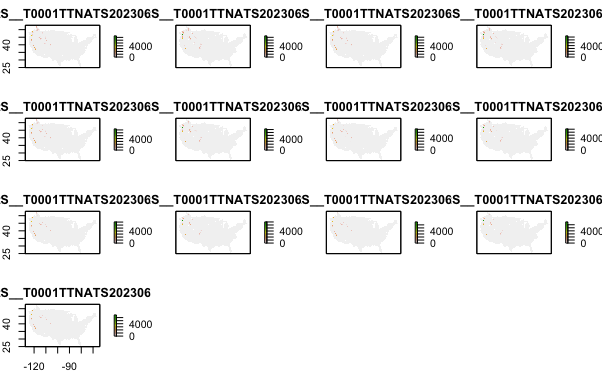

```r
plot(ras_stack)
```

### Save RasterStack

Save the RasterStack to a new directory. We will write in the “raster”/native format to preserve layer names (i.e. dates). There is no attribute table because there is only one attribute per file (snow depth in mm).

```r
#setwd("/Users/jero7025/Documents/NOAA/Datasets/G02158/R_code/Snow Depth/Rasters")
dir.create(paste(WD,"/Snow Depth","/Rasters",sep=""))
fp <- paste(WD,"/Snow Depth","/Rasters",sep="")
writeRaster(ras_stack,filename=file.path(fp,"ras_stack.grd"), format="raster", progress="text", options=c("INTERLEAVE=BAND","COMPRESS=LZW"))
```

## 3. Learning outcomes recap

We have learned how to: 1. Download and unzip masked SNODAS files 2. Convert the files to .bil format and put them in a raster stack 3. Quickly visualize the rasters of the data 4. Save the raster stack as .grd file